# **Modelación de la física en el ambiente construido: Dinámica**

## **Movimientos periódicos**

### M. en C. Jonathan A. Urrutia Anguiano

### AR108B

### ¿Qué trabajaremos en esta sesión?

En esta ocasión estudiaremos los siguientes conceptos

- Radianes
- Frecuencia
- Ondas (introducción)

### Los radianes

Si consideramos el total de la circunferencia del círculo, la longitud de arco es igual a su perímetro, es decir $$ s = r (2\pi).$$

[figure not shown]

Si, por el contrario consideramos cualquier otro desplazamiento angular, en la expresión anterio se sutituye $2\pi$ por $\theta$, por lo que en general se tiene la expresion: $$ s = r \theta.$$ Notemos que si se despeja el desplzamiento angular, se tiene una variable adimensional; esta variable se empleará para definir los ángulos de ahora en adelante y se le dará por nombre a esta unidad como **radian**: Para convertir de radianes a grados, o al revés, notemos que una vuelta completa al círculo es $360^\circ$, como también $2\pi$ radianes, por tanto $$ 2\pi (\text{rad}) = 360^\circ (\text{grado}) \quad\Longrightarrow\quad \pi = 180^\circ. $$

Kleppner, Daniel, y Robert J. Kolenkow. "An Introduction to Mechanics". Cambridge University Press, 2010

## Osciladores: Resortes

[figure not shown]

[Ivan Airola](https://commons.wikimedia.org/wiki/File:Easy_harmonic_oscillator.gif), [CC BY-SA 4.0](https://creativecommons.org/licenses/by-sa/4.0), via Wikimedia Commons

### Revisitando la ley de Hooke

Describe el comportamiento de materiales que pueden deformarse $$ F = - k (x-x_0) \hat{e}_x = - k \Delta x \hat{e}_x.$$ Considerando la segunda ley de Newton $$ m \mdv{x}{t}{2} + k x = 0\quad\Longrightarrow\quad \mdv{x}{t}{2} + \frac{k}{m}x = 0,$$ donde $x = x(t)$. Notemos que la solución a la ecuación anterior es $$ \begin{aligned} x_1(t) = &A_1 \cos\left(\sqrt{\frac{k}{m}}t\right), & x_2(t) = A_2 \sin\left(\sqrt{\frac{k}{m}}t\right). \end{aligned} $$ Definiendo la frecuencia de oscilación $\omega$ como $$ \omega^2 = k/m.$$

[figure not shown]

[MikeRun](https://commons.wikimedia.org/wiki/File:Spring-elongation-and-forces.svg), [CC BY-SA 4.0](https://creativecommons.org/licenses/by-sa/4.0), via Wikimedia Commonss

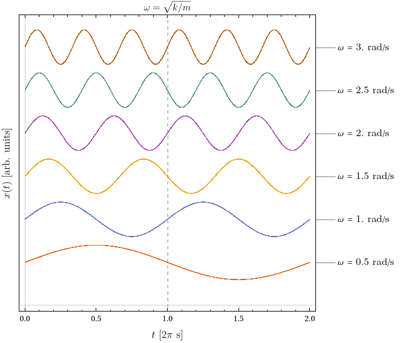

### Frecuencia angular vs. frecuencia

Notemos que las unidades de $\omega$, conocida como frecuencia angular, son $$ \omega\, [=]\, \text{rad}\cdot\frac{1}{s}. $$ Dado que $2\pi$ rad = $1$ ciclo, entonces se puede definir la frecuencia $f$ de oscilación como $$ f = \frac{\omega}{2\pi}\,[=] \,\frac{\text{ciclo}}{s} = \text{Hz}.$$

## Osciladores: Péndulos

[figure not shown]

[This SVG version by Maschen, based on user:Gurjete Ukaj's File:Pendulum.gif.](https://commons.wikimedia.org/wiki/File:Simple_pendulum_generalized_coordinates.svg), CC0, via Wikimedia Commons

[Stündle (modification Ideophagous)](https://commons.wikimedia.org/wiki/File:Pendulum-no-text.gif), [CC BY-SA 4.0](https://creativecommons.org/licenses/by-sa/4.0), via Wikimedia Commons

### Aproximación de ángulos pequeños

Dado que la tensión de la cuerda impide que el movimiento radia hacia fuera del círculo, la única contribución de la fuerza da como resultado, en la segunda ley de Newton $$ m \ell^2\mdv{\theta}{t}{2} + \ell mg\sin\theta = 0\quad\Longrightarrow\quad \mdv{\theta}{t}{2} + \frac{g}{\ell}\sin\theta = 0,$$ donde $\theta = \theta(t)$. Notemos que si $\theta\ll 1$, entonces $\sin\theta \sim \theta$, por lo quee $$ \begin{aligned} &\mdv{\theta}{t}{2} + \frac{g}{\ell}\theta = 0,\\ \theta_1(t) = &A_1 \cos\left(\sqrt{\frac{g}{\ell}}t\right), & \theta_2(t) = A_2 \sin\left(\sqrt{\frac{g}{\ell}}t\right). \end{aligned} $$ Definiendo la frecuencia de oscilación $\omega$ como $$ \omega^2 = g/\ell.$$

[figure not shown]

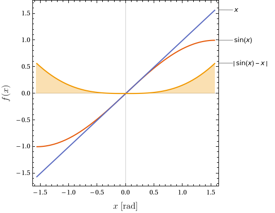